# ggplot2 - quick and easy

### Visualize a scatter plot layer

Since I have two numeric variables, `height` and `mass`, I’ll start with a scatter plot. Scatter plots are generated by the `geom_point()` function.

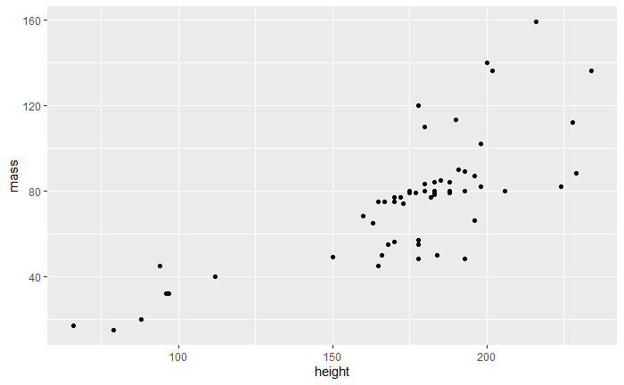

```r
starwars %>%
  filter(mass < 500) %>%
  ggplot(aes(height, mass)) +
  geom_point()
```

### Global v local arguments

- Mapping aesthetics in the ggplot argument maps aesthetics as global arguments (above)
- Arguments can also be set locally in the local layer function

#### `aes()` arguments mapped *locally* in `geom_point()`

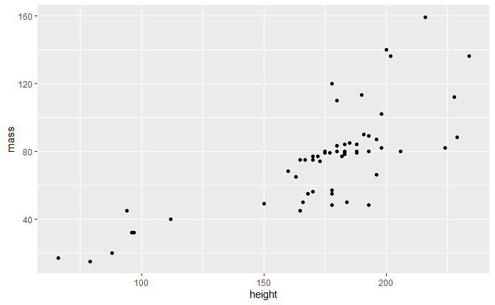

```r
starwars %>%
  filter(mass < 500) %>%
  ggplot() +
  geom_point(aes(height, mass))
```

### Mapping v Setting

Many arguments can be *mapped* inside the aesthetic, `aes()`, to leverage variable values, **OR** *set* outside the `aes()` but inside the geom_ function.

Aesthetic arguments include:

- color
- fill
- size
- linetype
- opacity
- shape
- *and more* see documentation for each geom_

#### Mapping: `color` is **mapped** *inside* `aes()` function

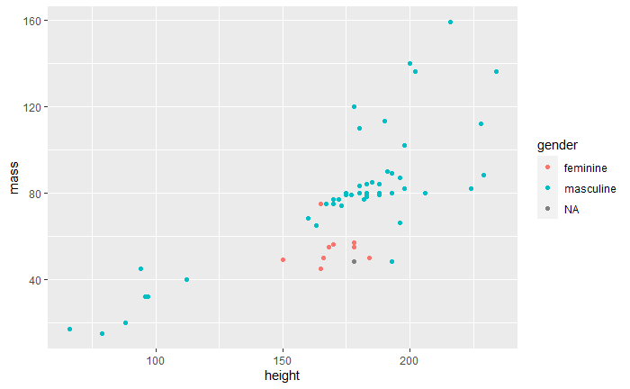

```r
starwars %>%
  filter(mass < 500) %>%
  ggplot() +
  # geom_point(mapping = aes(x = height, y = mass, color = gender))
  geom_point(aes(height, mass, color = gender))
```

Notice the legend was drawn automatically, above, by mapping an aesthetic

#### Setting: `color` **set** *outside* the `aes()` function

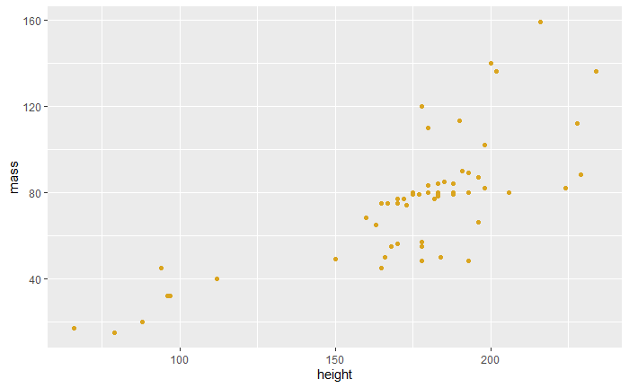

```r
starwars %>%
  filter(mass < 500) %>%
  ggplot() +
  geom_point(aes(height, mass), color = "goldenrod")
```

## Common geom_ functions

| Type | Geom |
| --- | --- |
| Bar graph: | `geom_bar()` `geom_col()` |
| Histogram: | `geom_hist()` |
| Scatter plot: | `geom_point()` `geom_jitter()` |
| Line graph: | `geom_line()` |
| Box plot: | `geom_boxplot()` |
| Density: | `geom_density()` `geom_violin()` |
| Heat map: | `geom_heatmap()` |
| Mapping: | `geom_sf()` |
| Regression line: | `geom_smooth()` |

> A list of available geom_ functions, or layers, can be found in the help or on the website: https://ggplot2.tidyverse.org/reference/index.html#section-geoms

### Boxplot

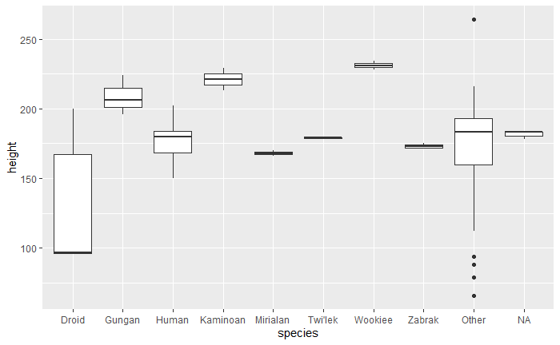

```r
starwars %>%
  mutate(species = fct_lump_min(species, 2)) %>%
  ggplot(aes(species, height)) +
  geom_boxplot()
```

### Line graph

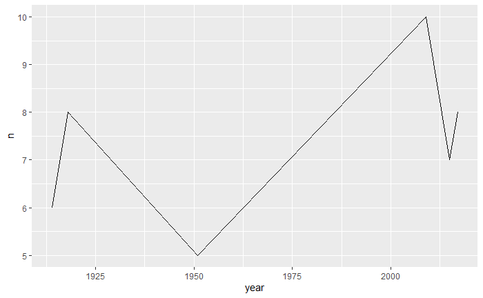

```r
babynames::babynames %>%
  filter(name == "Watts") %>%
  ggplot(aes(year, n)) +
  # geom_point() +
  geom_line()
```

### Multiple layers

Each layer can support local arguments and draw from the global settings.

```
babynames %>%
  ggplot(aes(year, prop)) +
  geom_line(aes(color = sex)) +
  geom_point(alpha = 0.4, shape = "cross")
```

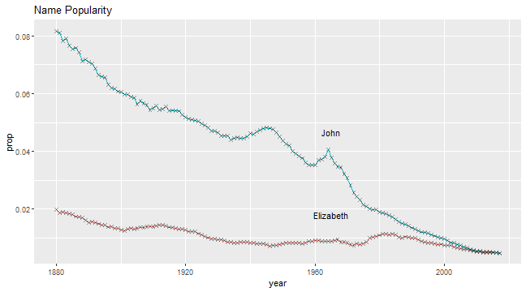

But there is more to that graph, here’s the bull code:

```
library(babynames)
library(ggplot)

babynames %>%
  filter(name == "John" & sex == "M" |
           name == "Elizabeth" & sex == "F") %>%
  ggplot(aes(year, prop)) +
  geom_line(aes(color = sex)) +
  geom_point(alpha = 0.4, shape = "cross") +
  geom_text(data = . %>% filter(year == 1965), aes(label = name),
            nudge_y = .009) +
  labs(title = "Name Popularity") +
  theme(legend.position = "none")
```

## Facet warp

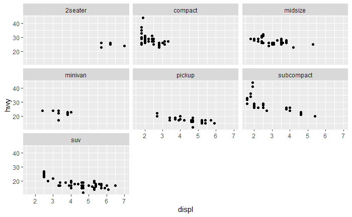

```r
mpg %>%
  ggplot(aes(displ, hwy)) +
  geom_point() +
  facet_wrap(~ class)
```

## Labels

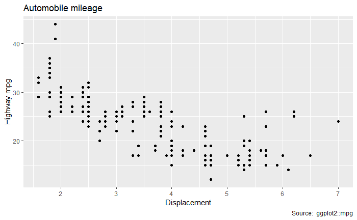

```r
mpg %>%
  ggplot(aes(displ, hwy)) +
  geom_point() +
  labs(title = "Automobile mileage",
       x = "Displacement", y = "Highway mpg",
       caption = "Source:  ggplot2::mpg")
```

## Arrange order

Categorical values are most easily ordered with the `forcats` library. Part of the tidyverse, forcats will convert string data into factors, or categorical data. This enables ordering

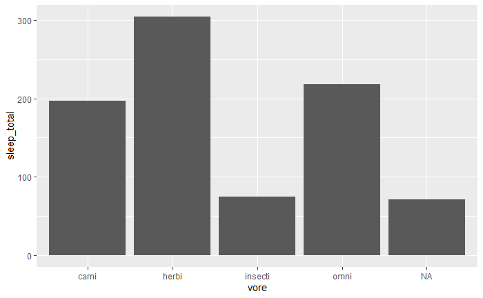

```r
msleep %>%
  ggplot(aes(vore, sleep_total)) +
  geom_col()
```

### forcats::fct_infreq()

Change the order by the number of observations.

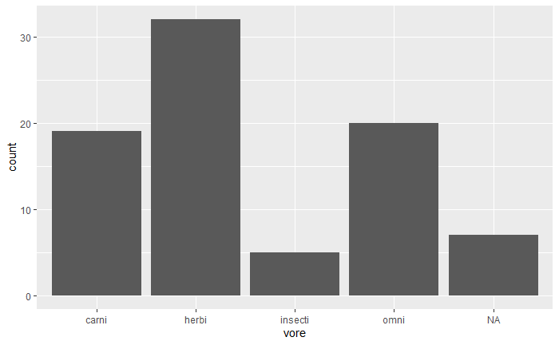

```r
msleep %>%
  ggplot(aes(vore)) +
  geom_bar()
```

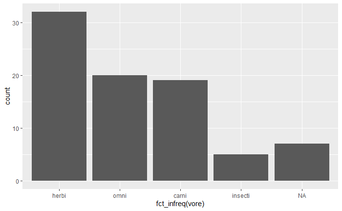

```r
msleep %>%
  ggplot(aes(fct_infreq(vore))) +
  geom_bar()
```

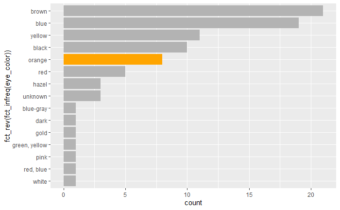

```r
starwars %>%
  ggplot(aes(fct_rev(fct_infreq(eye_color)))) +
  geom_bar(fill = "grey70") +
  geom_bar(data = starwars %>% filter(eye_color == "orange"), fill = "orange") +
  coord_flip()
```

```r
NA
```

## Scales

https://ggplot2.tidyverse.org/reference/index.html#section-scales

The viridis scales can apply color palettes to continuous, discrete, or binned data

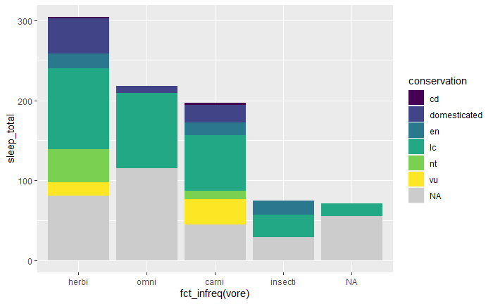

```r
msleep %>%
  ggplot(aes(fct_infreq(vore), sleep_total)) +
  geom_col(aes(fill = conservation)) +
  scale_fill_viridis_d(na.value = "grey80")
```

The color brewer palette is similar but has a wider array of palettes to choose from.

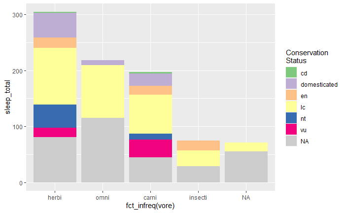

```r
msleep %>%
  ggplot(aes(fct_infreq(vore), sleep_total)) +
  geom_col(aes(fill = conservation)) +
  scale_fill_brewer(type = "qual", na.value = "grey80", name = "Conservation\nStatus")
```

To find available colors: Google search “R color names”, or specific to ColorBrewer….

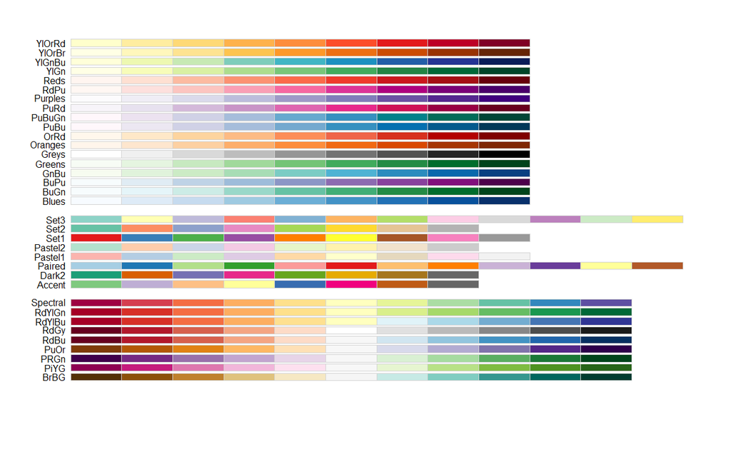

```r
#display.brewer.pal(7,"Dark2")
RColorBrewer::display.brewer.all()
```

## Labels

using the `labs()` function

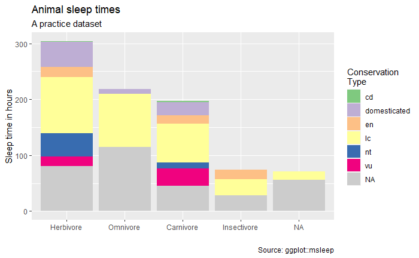

```r
plot_sleep <- msleep %>%
  mutate(vore = case_when(
    vore == "herbi" ~ "Herbivore",
    vore == "omni"  ~ "Omnivore",
    vore == "carni" ~ "Carnivore",
    vore == "insecti" ~ "Insectivore"
  ))  %>%
  ggplot(aes(fct_infreq(vore), sleep_total)) +
  geom_col(aes(fill = conservation)) +
  scale_fill_brewer(type = "qual", na.value = "grey80") +
  labs(title = "Animal sleep times",
       subtitle = "A practice dataset",
       fill = "Conservation\nType",
       x = "",
       y = "Sleep time in hours",
       caption = "Source: ggplot::msleep")

plot_sleep
```

## Themes

- https://ggplot2.tidyverse.org/reference/ggtheme.html
  - for example… `theme_dark()`, `theme_light()`, `theme_classic()`
- https://cinc.rud.is/web/packages/hrbrthemes/
- https://yutannihilation.github.io/allYourFigureAreBelongToUs/ggthemes/

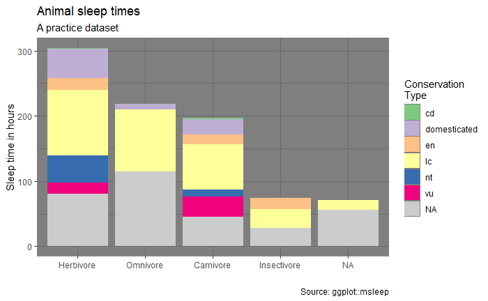

```r
plot_sleep +
  theme_dark()
```

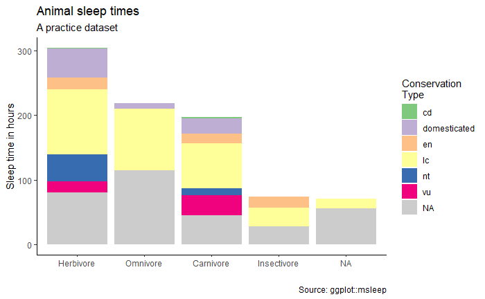

```r
plot_sleep +
  theme_classic()
```

### hbrthemes

https://cinc.rud.is/web/packages/hrbrthemes/

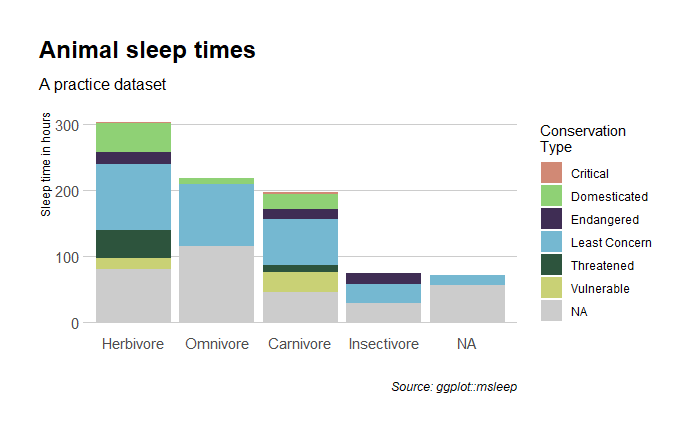

```r
plot_sleep +
  hrbrthemes::theme_ipsum(grid = "Y") +
  hrbrthemes::scale_fill_ipsum(na.value = "grey80",
                               labels = c("Critical", "Domesticated",
                                          "Endangered", "Least Concern",
                                          "Threatened", "Vulnerable")) +
  theme(plot.title.position = "plot")
```